# Preliminary Results from Age Manipulation Experiment

Joel Pick

We essentially have 5 groups - day 6 control (C6), day 9 control (C9), day 6 experimental (E6), day 9 experimental E9, and odd (O). Day 9 controls are systematically 3 days earlier than day 6 controls, so these can unambiguously be referred to as early and late controls respectively. The experimental groups, however, differ on whether the you are referring to the parents or the chicks originating in that nest. Nests assigned to E9 treatment have parents that experience extended care, but chicks that move into a E6 nest, and so end up with reduced care parents. The experimental group of the parents is not ambiguous, and for the chicks we will refer to their treatment as that of the nest they are swapped into, and so chicks in the experimental treatment are in the opposite treatment group to their original parents.

From the point of view of the chicks, the appropriate control for E6 chicks are C9 chicks and visa versa. From the point of view of the parents, it is difficult to tell which the appropriate controls are; E9 parents have chicks that hatch on average 3 days earlier than E6 parents, but fledge on average 3 days later.

The adult has bred early, but the chicks have hatched late

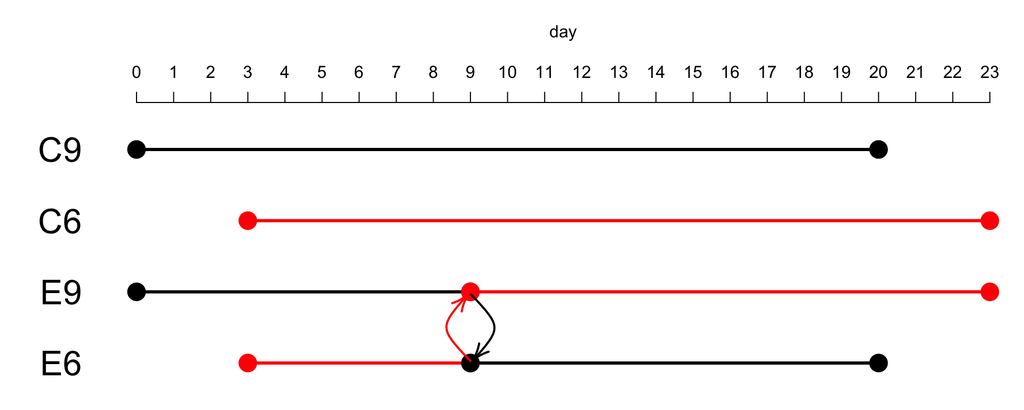

# 1 General Results

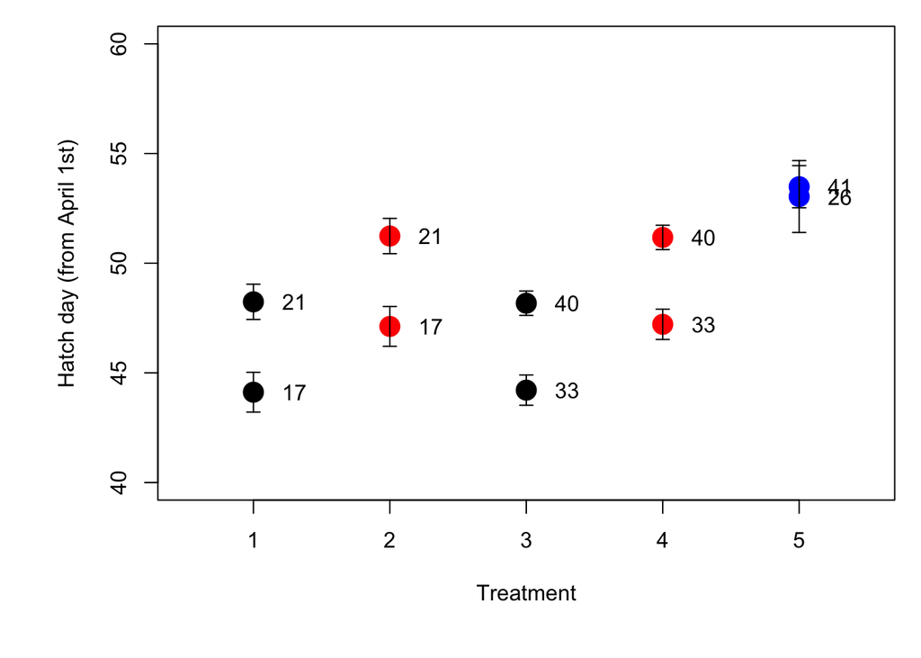

# 2 Chicks

Ideally we would see no difference between treatments in the chicks, as this would indicate that the parents had fully compensated for the change in chick age, and our manipulation had led to an increase/reduction in parental care.

## 2.1 Chick Growth

We can first look at the growth of nestlings up until day 15.

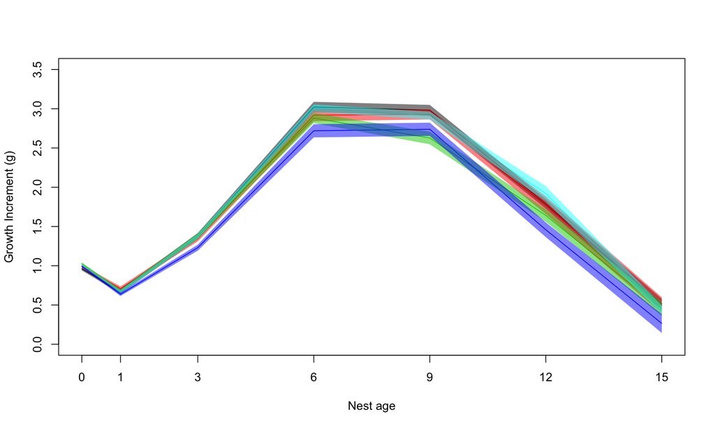

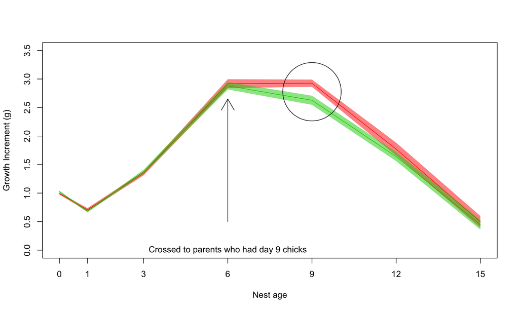

Comparing the late control to chicks in the extended care treatment (both sets of broodd hatched at similar times), the growth of the experimental broods is clearly lower at day 9, the first timepoint they are measured after having being crossed. This reduction in growth is not perpetuated however, and growth at later timepoints is not reduced compared to controls.

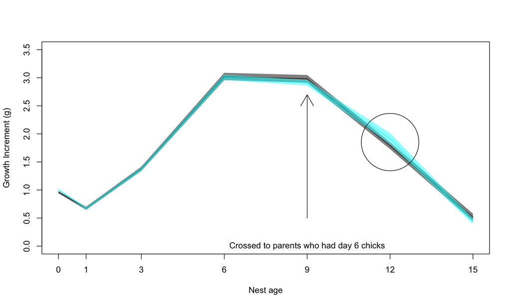

Comparing the early control to chicks in the reduced care treatment (both of which hatched at similar times), the growth of the experimental broods is slightly higher at day 12, the first timepoint they are measured after having being crossed. Again this difference in growth is not perpetuated however, and growth at later timepoints is not different from to controls.

The reduction in growth at day 9 in the extended group alone suggests that the cross fostering procedure has a negative impact on the chicks. However, the reduced treatment broods appear to benefit from the cross. We had no prediction that cross fostering would benefit either group, rather that it would, if anything, have a negative effect. Therefore it perhaps rather suggests a difference in the ability of the parents to fully change their behaviour. Indeed a study in house sparrows (Pelletier et al. 2016) which switched broods in a similar way for short time periods (2 hours) showed that younger chicks had reduced growth when crossed into an older nest, whereas if anything, the older chicks gained when crossed into a younger nest. Interestingly, the older chicks growth was also reduced when being crossed from the younger nest back to the older nest.

If the parents extended care treatment where not able to compensate through having to care for longer, we would expect to see the mass growth difference emerge at later stages, which we do not see.

## 2.2 Chick Day 15 Mass

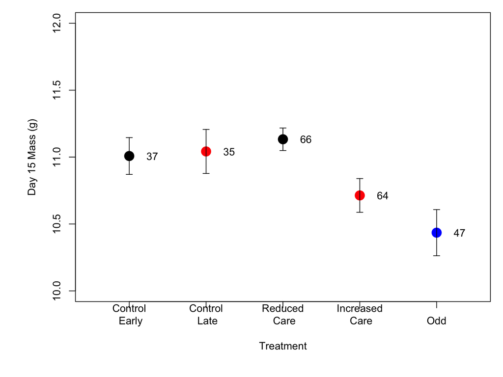

## 2.3 Nestling Mortality

Clearly higher mortality in ‘odd’ treatment group. This is partly because all broods that failed before on on the day of crossing were put into the odd group, but also because the odd group contains mainly the very early or late hatching broods, which generally suffer higher mortality.

Higher mortality is seen in broods that hatch later, both in terms of proportion of total nestlings dying and total brood failure. Experimental groups also appear to have higher mortality then their corresponding control, particularly in the case of the increased care group. This suggests a general negative effect of cross fostering. This may be the consequence of crossing good broods into bad nests (effect of brood mass of nest going into rather than of your brood mass).

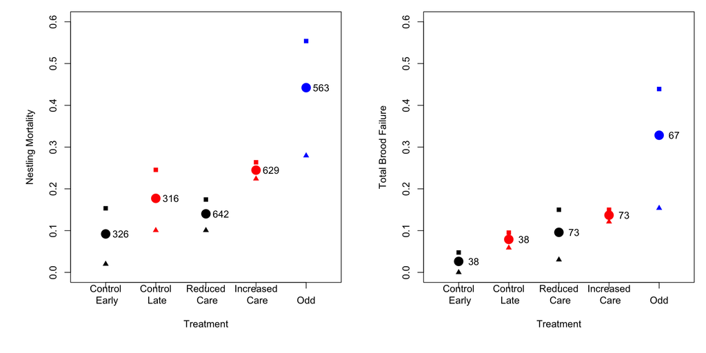

## 2.4 Chick Recruitment

Whereas the other chick measures reflect two years of data, we only have recruitment data from chicks hatched in 2019. This is based on the identity of the caught adults, but will change with genotyping chicks from nests where we didn’t catch adults.

Generally, chicks hatching earlier appear to have higher recruitment. Both experimental groups have slightly higher recruitment than their relevant controls.

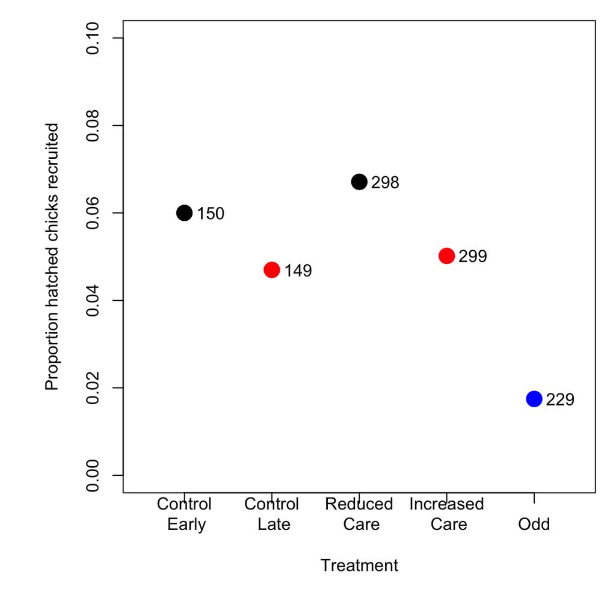

## 2.5 Nestling Period

The hatching date of the chicks is more important than the hatch date of the parents - actual date more important than ‘parent quality’.

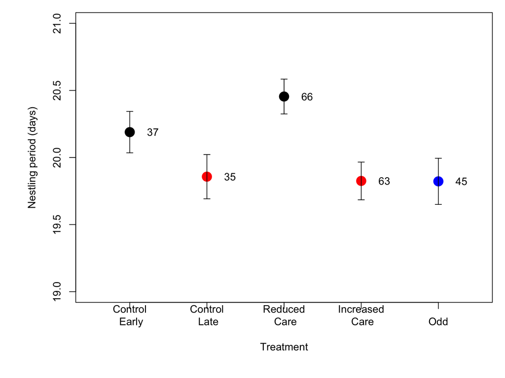

# 3 Adults

We can also think of the nestling period from the perspective of the parents.

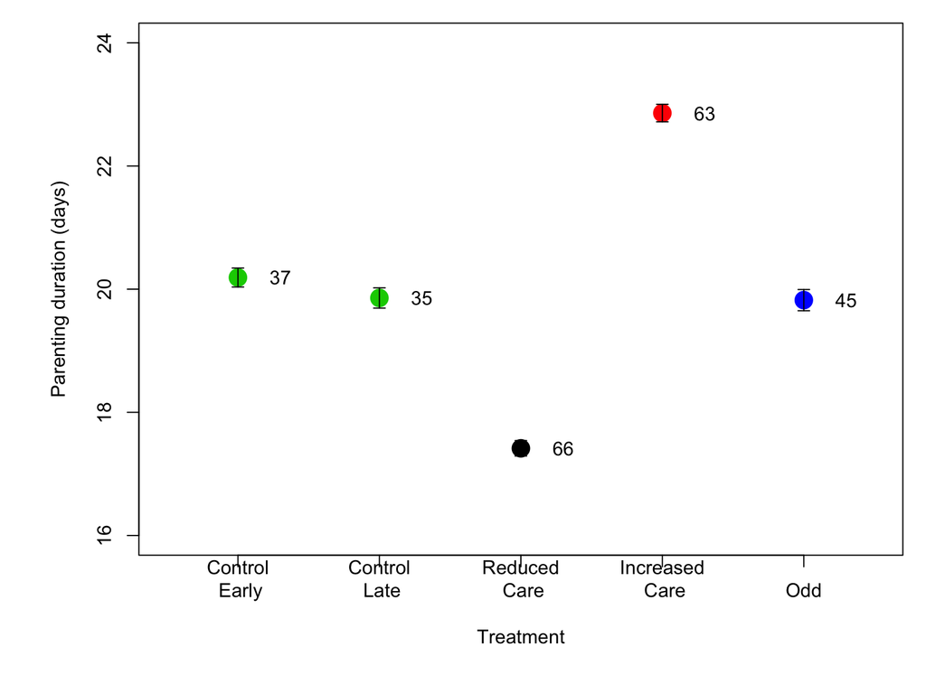

## 3.1 Adult Mass

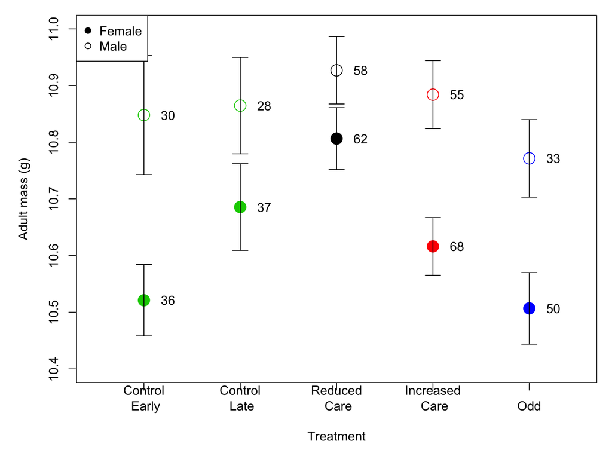

## 3.2 Adult Survival

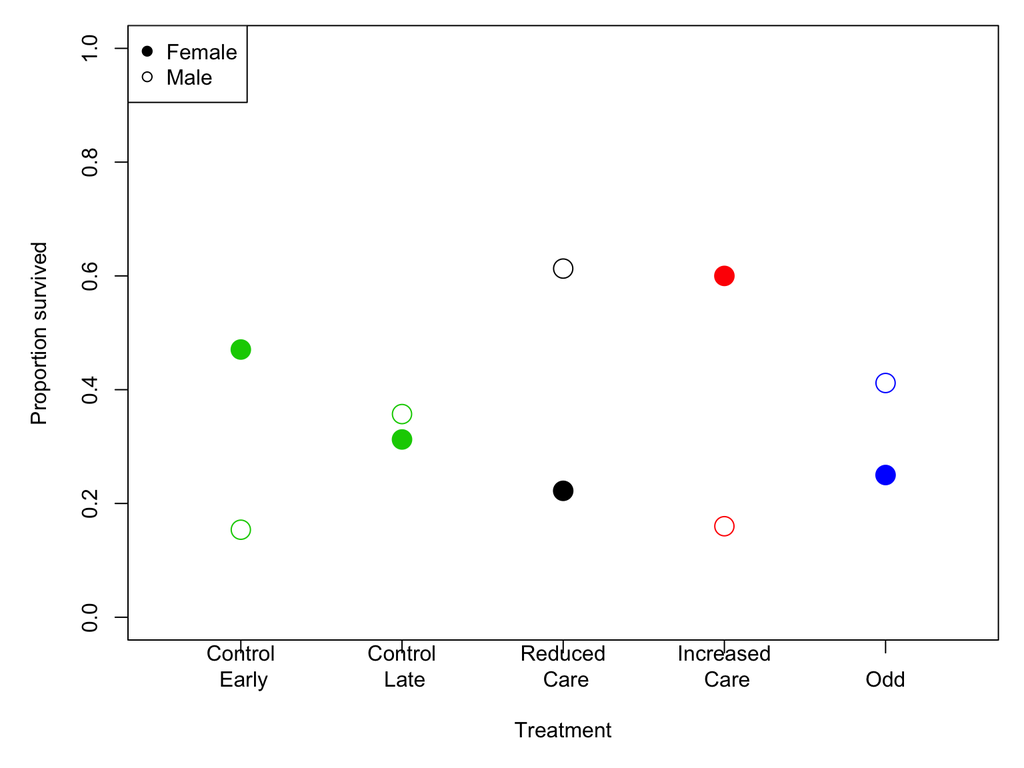

## 3.3 Adults Future Fecundity